# Naive Bayes Classification using Package mlr

Data Mining

Description for Naive Bayes Classification using Package mlr

Yeongeun Jeon , Jung In Seo  
2023-07-18

> Naive Bayes의 장점
- 연속형과 범주형 예측 변수 모두 가능하다.
- 튜닝(Tuning)해야 하는 초모수(Hyperparameter)가 없다.
- Topic 분류 문제에 잘 작동한다.

> Naive Bayes의 단점
- 연속형 예측 변수는 정규 분포를 가정한다.
- 예측 변수들은 서로 독립이어야 한다.

# **1. 패키지 불러오기**

```r
# Install mlr Package
# install.packages("mlr", dependencies = TRUE) # could take several minutes

# Package Loading
pacman::p_load("mlr",
               "tidyverse")
```

# **2. 데이터 불러오기**

- 분석을 위해 사용할 데이터셋은 Package `"mlbench"`에서 제공하는 `HouseVotes84` 데이터셋이다.
- 해당 데이터셋은 미국 하원 의원들이 CQA(Congressional Quarterly Almanac)에서 식별한 16개의 주요 표결에 대해 투표한 내용이 포함되어 있다.
  1. `Class` : 투표한 의원의 정당 이름으로 “democrat”와 “republican”로 구분되어 있다.
  2. 16개의 주요 표결에 대한 투표 결과로 찬성은 “y”, 반대는 “n”으로 구분되어 있다.

```r
data(HouseVotes84, package = "mlbench")   # Data Loading

votesTib <- HouseVotes84 %>%
  as_tibble                               # Tibble 형태로 변환

votesTib
```

```
# A tibble: 435 × 17
   Class   V1    V2    V3    V4    V5    V6    V7    V8    V9    V10
   <fct>   <fct> <fct> <fct> <fct> <fct> <fct> <fct> <fct> <fct> <fct>
 1 republ… n     y     n     y     y     y     n     n     n     y
 2 republ… n     y     n     y     y     y     n     n     n     n
 3 democr… <NA>  y     y     <NA>  y     y     n     n     n     n
 4 democr… n     y     y     n     <NA>  y     n     n     n     n
 5 democr… y     y     y     n     y     y     n     n     n     n
 6 democr… n     y     y     n     y     y     n     n     n     n
 7 democr… n     y     n     y     y     y     n     n     n     n
 8 republ… n     y     n     y     y     y     n     n     n     n
 9 republ… n     y     n     y     y     y     n     n     n     n
10 democr… y     y     y     n     n     n     y     y     y     n
# ℹ 425 more rows
# ℹ 6 more variables: V11 <fct>, V12 <fct>, V13 <fct>, V14 <fct>,
#   V15 <fct>, V16 <fct>
```

```r
glimpse(votesTib)                         # 데이터 구조 확인
```

```
Rows: 435
Columns: 17
$ Class <fct> republican, republican, democrat, democrat, democrat, …
$ V1    <fct> n, n, NA, n, y, n, n, n, n, y, n, n, n, y, n, n, y, y,…
$ V2    <fct> y, y, y, y, y, y, y, y, y, y, y, y, y, y, y, y, n, NA,…
$ V3    <fct> n, n, y, y, y, y, n, n, n, y, n, n, y, y, n, n, y, y, …
$ V4    <fct> y, y, NA, n, n, n, y, y, y, n, y, y, n, n, y, y, n, n,…
$ V5    <fct> y, y, y, NA, y, y, y, y, y, n, y, y, n, n, y, y, n, n,…
$ V6    <fct> y, y, y, y, y, y, y, y, y, n, n, y, n, y, y, y, y, n, …
$ V7    <fct> n, n, n, n, n, n, n, n, n, y, n, n, y, y, n, n, n, y, …
$ V8    <fct> n, n, n, n, n, n, n, n, n, y, n, n, y, y, n, n, y, y, …
$ V9    <fct> n, n, n, n, n, n, n, n, n, y, n, n, y, NA, n, n, NA, y…
$ V10   <fct> y, n, n, n, n, n, n, n, n, n, n, n, n, y, n, y, y, n, …
$ V11   <fct> NA, n, y, y, y, n, n, n, n, n, NA, y, n, y, n, n, y, n…
$ V12   <fct> y, y, n, n, NA, n, n, n, y, n, NA, NA, n, NA, y, y, y,…
$ V13   <fct> y, y, y, y, y, y, NA, y, y, n, y, y, y, n, NA, y, NA, …
$ V14   <fct> y, y, y, n, y, y, y, y, y, n, y, y, n, n, NA, NA, n, n…
$ V15   <fct> n, n, n, n, y, y, y, NA, n, NA, n, NA, NA, y, n, n, n,…
$ V16   <fct> y, NA, n, y, y, y, y, y, y, NA, n, NA, NA, NA, NA, NA,…
```

```r
summary(votesTib)                         # 데이터 요약
```

```
        Class        V1         V2         V3         V4
 democrat  :267   n   :236   n   :192   n   :171   n   :247
 republican:168   y   :187   y   :195   y   :253   y   :177
                  NA's: 12   NA's: 48   NA's: 11   NA's: 11
    V5         V6         V7         V8         V9        V10
 n   :208   n   :152   n   :182   n   :178   n   :206   n   :212
 y   :212   y   :272   y   :239   y   :242   y   :207   y   :216
 NA's: 15   NA's: 11   NA's: 14   NA's: 15   NA's: 22   NA's:  7
   V11        V12        V13        V14        V15        V16
 n   :264   n   :233   n   :201   n   :170   n   :233   n   : 62
 y   :150   y   :171   y   :209   y   :248   y   :174   y   :269
 NA's: 21   NA's: 31   NA's: 25   NA's: 17   NA's: 28   NA's:104
```

# **3. 변수들 특성 확인**

```r
map_dbl(votesTib, ~ sum(is.na(.)))
```

```
Class    V1    V2    V3    V4    V5    V6    V7    V8    V9   V10
    0    12    48    11    11    15    11    14    15    22     7
  V11   V12   V13   V14   V15   V16
   21    31    25    17    28   104
```

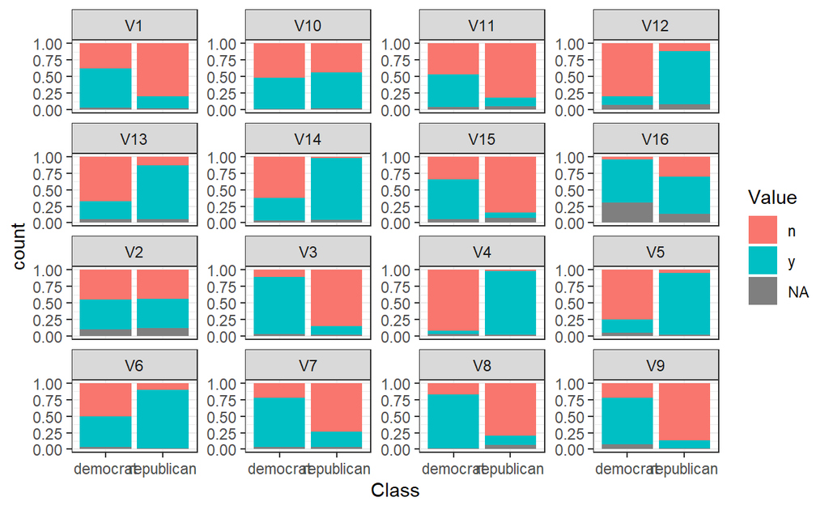

```r
votesUntidy <- gather(votesTib, "Variable", "Value", -Class)      # pivot_longer

ggplot(votesUntidy, aes(Class, fill = Value)) +
  facet_wrap(~ Variable, scales = "free_y") +
  geom_bar(position = "fill") +
  theme_bw()
```

# **4. 데이터 분할**

```r
# Partition (Training Dataset : Test Dataset = 7:3)
pacman::p_load("caret")                                         # For createDataPartition

y <- votesTib$Class                                             # Target

set.seed(200)
ind       <- createDataPartition(y, p = 0.7, list = T)          # Index를 이용하여 7:3으로 분할
votes.trd <- votesTib[ind$Resample1,]                           # Training Dataset
votes.ted <- votesTib[-ind$Resample1,]                          # Test Dataset

detach(package:caret)
```

# **5. 모델링**

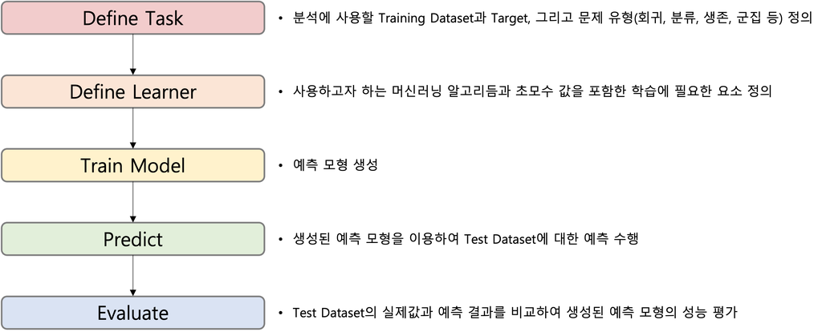

## **5-1. Define Task**

- 문제 유형에 따라 Task를 정의하는 데 사용하는 함수는 다음과 같다.

| 문제 유형 | 함수 |
| --- | --- |
| 회귀 문제 | `makeRegrTask` |
| 이진 또는 다중 클래스 분류 문제 | `makeClassifTask` |
| 생존 분석 | `makeSurvTask` |
| 군집 분석 | `makeClusterTask` |
| 다중 라벨 분류 문제 | `makeMultilabelTask` |
| 비용 민감 분류 문제 | `makeCostSensTask` |

```r
# Naive Bayes : 이진 클래스 분류 문제
votesTask <- makeClassifTask(data = votes.trd,        # Training Dataset
                             target = "Class")        # Target

votesTask
```

```
Supervised task: votes.trd
Type: classif
Target: Class
Observations: 305
Features:
   numerics     factors     ordered functionals
          0          16           0           0
Missings: TRUE
Has weights: FALSE
Has blocking: FALSE
Has coordinates: FALSE
Classes: 2
  democrat republican
       187        118
Positive class: democrat
```

`Caution!` 클래스 분류 문제에서 Target은 범주형이어야 한다. 특히, 이진 클래스 분류 문제에서, 함수 `makeClassifTask`는 Target의 첫 번째 “level”을 관심 클래스로 인식한다. 만약 두 번째 “level”이 관심 클래스라면, 인자 `positive`에 두 번째 “level”을 지정해야 한다.

## **5-2. Define Learner**

- 학습자(Learner)는 함수 `makeLearner`를 이용하여 정의한다.
- 함수 `makeLearner`의 첫 번째 인자 `cl`에는 사용하고자 하는 머신러닝 알고리듬을 `문제 유형.알고리듬과 관련된 R 함수 이름` 형태로 입력한다.
  - 예를 들어,
    - 회귀 문제 : `"regr.알고리듬과 관련된 R 함수 이름"`
    - 클래스 분류 문제 : `"classif.알고리듬과 관련된 R 함수 이름"`
    - 생존 분석 : `"surv.알고리듬과 관련된 R 함수 이름"`
    - 군집 분석 : `"cluster.알고리듬과 관련된 R 함수 이름"`
    - 다중 라벨 문제 : `"multilabel.알고리듬과 관련된 R 함수 이름"`
  - Package `"mlr"`에서 사용할 수 있는 알고리듬은 [여기](https://mlr.mlr-org.com/articles/tutorial/integrated_learners.html)를 통해서 확인할 수 있다.

```r
# Check Hyperparameter Set
getParamSet("classif.naiveBayes")
```

```
           Type len Def   Constr Req Tunable Trafo
laplace numeric   -   0 0 to Inf   -    TRUE     -
```

`Result!` 특정 머신러닝 알고리듬이 가지고 있는 초모수는 함수 `getParamSet`을 이용하여 확인할 수 있다.

```r
# Define Naive Bayes Learner
bayes <- makeLearner(cl = "classif.naiveBayes",
                     predict.type = "prob")                      # For 예측 확률과 class 생성

bayes
```

```
Learner classif.naiveBayes from package e1071
Type: classif
Name: Naive Bayes; Short name: nbayes
Class: classif.naiveBayes
Properties: twoclass,multiclass,missings,numerics,factors,prob
Predict-Type: prob
Hyperparameters:
```

`Caution!` 함수 `makeLearner`의 옵션 `predict.type = "prob"`를 지정하면 예측 확률과 class를 함께 생성할 수 있다. 하지만 `"classif.knn"`과 같이 예측 확률을 생성할 수 없는 알고리듬이 있기 때문에 옵션을 항상 이용할 수는 없다.

## **5-3. Train Model**

```r
bayesModel <- train(bayes, votesTask)                   # train(Defined Learner in 5-2, Defined Task in 5-1)

bayesModel
```

```
Model for learner.id=classif.naiveBayes; learner.class=classif.naiveBayes
Trained on: task.id = votes.trd; obs = 305; features = 16
Hyperparameters:
```

```r
getLearnerModel(bayesModel)                             # Extract Trained Model
```

```
Naive Bayes Classifier for Discrete Predictors

Call:
naiveBayes.default(x = X, y = Y, laplace = laplace)

A-priori probabilities:
Y
  democrat republican
 0.6131148  0.3868852

Conditional probabilities:
            V1
Y                    n         y
  democrat   0.4055556 0.5944444
  republican 0.8189655 0.1810345

            V2
Y                    n         y
  democrat   0.4969697 0.5030303
  republican 0.5188679 0.4811321

            V3
Y                    n         y
  democrat   0.1318681 0.8681319
  republican 0.8448276 0.1551724

            V4
Y                      n           y
  democrat   0.945054945 0.054945055
  republican 0.008547009 0.991452991

            V5
Y                     n          y
  democrat   0.80225989 0.19774011
  republican 0.06034483 0.93965517

            V6
Y                    n         y
  democrat   0.5500000 0.4500000
  republican 0.1196581 0.8803419
```

[output cut: 35 more lines]

```

            V14
Y                     n          y
  democrat   0.65921788 0.34078212
  republican 0.01769912 0.98230088

            V15
Y                    n         y
  democrat   0.3743017 0.6256983
  republican 0.9266055 0.0733945

            V16
Y                     n          y
  democrat   0.07407407 0.92592593
  republican 0.33009709 0.66990291
```

## **5-4. Predict**

```r
# 예측 확률과 class 생성
bayesPred <- predict(bayesModel, newdata = votes.ted)    # predict(Trained Model, Test Dataset)

bayesPred
```

```
Prediction: 130 observations
predict.type: prob
threshold: democrat=0.50,republican=0.50
time: 0.03
       truth prob.democrat prob.republican   response
1   democrat  8.238201e-01    1.761799e-01   democrat
2   democrat  1.000000e+00    5.886008e-11   democrat
3 republican  7.645217e-06    9.999924e-01 republican
4   democrat  1.000000e+00    5.920266e-13   democrat
5   democrat  1.000000e+00    3.198378e-11   democrat
6   democrat  1.000000e+00    5.920266e-13   democrat
... (#rows: 130, #cols: 4)
```

```r
getPredictionProbabilities(bayesPred,                    # Extract 예측 확률 for Test Dataset
                           cl = c("democrat", "republican"))
```

```
        democrat   republican
1   8.238201e-01 1.761799e-01
2   1.000000e+00 5.886008e-11
3   7.645217e-06 9.999924e-01
4   1.000000e+00 5.920266e-13
5   1.000000e+00 3.198378e-11
6   1.000000e+00 5.920266e-13
7   1.000000e+00 8.182869e-13
8   1.011552e-08 1.000000e+00
9   1.000000e+00 9.488841e-10
10  9.999997e-01 2.572045e-07
11  1.000000e+00 5.920266e-13
12  3.915526e-07 9.999996e-01
13  1.000000e+00 5.886008e-11
14  6.707387e-08 9.999999e-01
```

[output cut: 116 more lines]

```r
getPredictionResponse(bayesPred)                         # Extract 예측 class for Test Dataset
```

```
  [1] democrat   democrat   republican democrat   democrat
  [6] democrat   democrat   republican democrat   democrat
 [11] democrat   republican democrat   republican republican
 [16] republican republican democrat   democrat   republican
 [21] democrat   republican republican republican republican
 [26] republican democrat   republican republican democrat
 [31] republican democrat   republican republican republican
 [36] republican republican democrat   republican democrat
 [41] democrat   republican republican republican democrat
 [46] democrat   democrat   democrat   democrat   republican
 [51] democrat   democrat   republican republican democrat
 [56] republican democrat   democrat   democrat   republican
 [61] republican democrat   democrat   democrat   republican
 [66] democrat   democrat   democrat   republican democrat
 [71] democrat   democrat   democrat   republican republican
 [76] democrat   democrat   democrat   democrat   democrat
 [81] democrat   republican republican republican democrat
 [86] republican republican democrat   democrat   democrat
 [91] democrat   democrat   republican republican democrat
 [96] democrat   democrat   democrat   democrat   republican
[101] republican democrat   republican republican republican
[106] republican republican democrat   democrat   democrat
[111] democrat   democrat   republican republican republican
[116] democrat   republican democrat   democrat   republican
[121] democrat   democrat   republican democrat   democrat
[126] republican republican democrat   democrat   democrat
Levels: democrat republican
```

## **5-5. Evaluate**

```r
# ConfusionMatrix
calculateConfusionMatrix(bayesPred,                     # 함수 predict의 결과
                         relative = TRUE)               # 비율도 함께 출력
```

```
Relative confusion matrix (normalized by row/column):
            predicted
true         democrat  republican -err.-
  democrat   0.89/0.97 0.11/0.16  0.11
  republican 0.04/0.03 0.96/0.84  0.04
  -err.-          0.03      0.16  0.08


Absolute confusion matrix:
            predicted
true         democrat republican -err.-
  democrat         71          9      9
  republican        2         48      2
  -err.-            2          9     11
```

```r
# Performance Measure
performance(bayesPred,                                  # 함수 predict의 결과
            measures = list(mmce, acc))                 # mmce : 평균 오분류율, acc : 정확도
```

```
      mmce        acc
0.08461538 0.91538462
```

`Caution!` 함수 `performance`의 인자 `measures`에 사용할 수 있는 평가척도는 [여기](https://mlr.mlr-org.com/articles/tutorial/measures.html)를 참고한다.

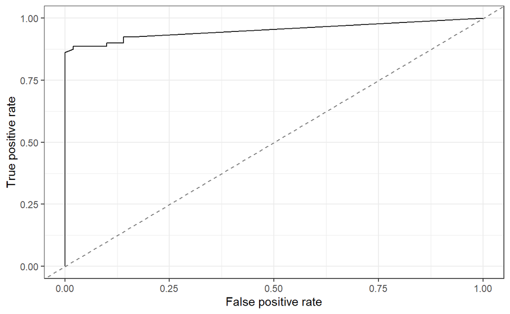

```r
# ROC 곡선
df <- generateThreshVsPerfData(bayesPred, measures = list(fpr, tpr))

plotROCCurves(df) +
  theme_bw()
```

```r
# AUC
performance(bayesPred,                                   # 함수 predict의 결과
            auc)
```

```
    auc
0.97975
```